# NAb-seq report

2022-10-30

## Introduction

Thank you for running `NAb-seq`, a Nextflow pipeline for analysing Oxford Nanopore sequencing data from hybridomas and single B cells!

For more information about the pipeline, check out our paper or [website](https://kzeglinski.github.io/nab-seq/NAb_seq_vignette.html) (which contains a detailed bioinformatics tutorial).

## Sample/run information

You have run version v0.2 of `NAb-seq` on the following **rat** samples:

| Barcode | Sample Name |
| --- | --- |
| barcode01 | sample_x |
| barcode02 | sample_y |
| barcode03 | sample_z |

## Quality control

This is a selection of the most relevant QC plots and summary statistics produced by NanoComp. A full QC report is available in the results folder.

|  | General summary: | sample_y | sample_x | sample_z |
| --- | --- | --- | --- | --- |
| 2 | Mean read length: | 677.4 | 693.1 | 684.8 |
| 3 | Mean read quality: | 14.0 | 14.0 | 14.1 |
| 4 | Median read length: | 599.0 | 607.0 | 590.0 |
| 5 | Median read quality: | 13.9 | 13.9 | 14.0 |
| 6 | Number of reads: | 12,000.0 | 12,000.0 | 12,000.0 |
| 7 | Read length N50: | 827.0 | 850.0 | 873.0 |
| 8 | STDEV read length: | 432.1 | 444.1 | 453.8 |
| 9 | Total bases: | 8,128,417.0 | 8,317,129.0 | 8,217,820.0 |

### Read number

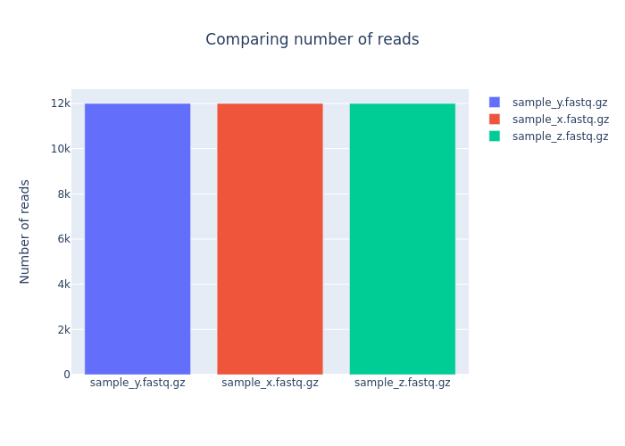

**How do I interpret this result?**

Best results are usually achieved with at least 40,000 reads per barcode. Below this it is often possible to generate high-accuracy consensus sequences, but not guaranteed.

### Read length

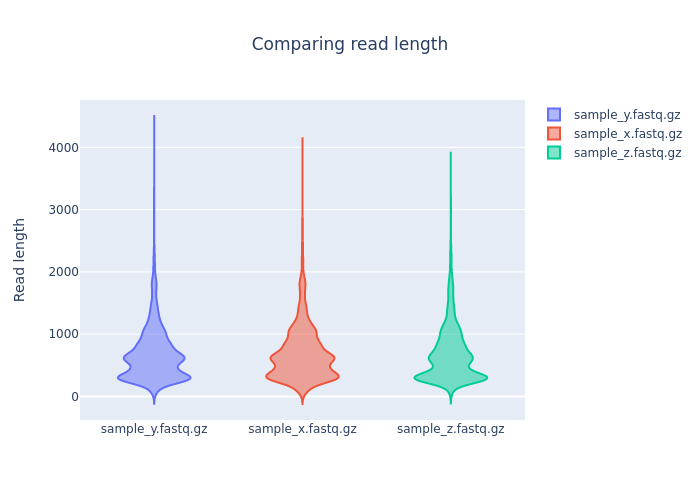

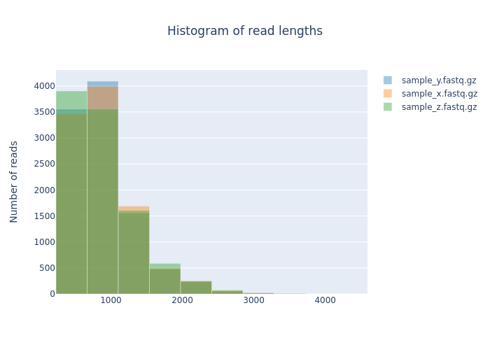

**How do I interpret this result?**

Although longer reads are more likely to recover full-length antibody sequences, `NAb-seq` will always use the longest reads to make consensus sequences. Thus, good results can be achieved even when most reads are <1 kb.

### Read quality

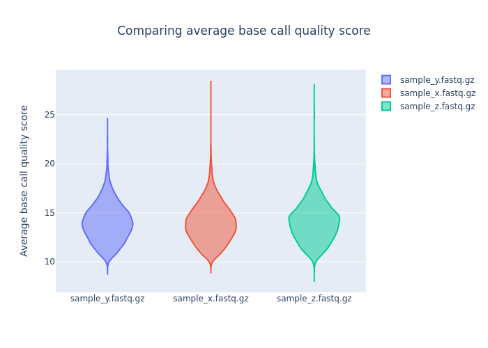

**How do I interpret this result?**

It is recommended that the reads used to run `NAb-seq` are basedcalled with the super high accuracy model, which has a Q score cutoff of 10 (~90% accuracy). If you have a lot of reads below this cutoff, the consensus sequences may still contain some errors (usually indels in homopolymer regions).

## Consensus sequences

### sample_x

| group_id | productive | v_call | d_call | j_call | cdr3_aa | v_identity | c_call | count |
| --- | --- | --- | --- | --- | --- | --- | --- | --- |
| sample_x_H1 | TRUE | IGHV5S13*01 | IGHD5-1*01 | IGHJ4*01 | ARQMGEAVMDA | 98.311 | IGHG2B*01 | 87 |
| sample_x_L1 | TRUE | IGKV3S9*01 |  | IGKJ2-3*01 | QQSWNDPYT | 96.797 | IGKC*02 | 275 |
| sample_x_L2 | TRUE | IGKV3S9*01 |  | IGKJ2-3*01 | QQSWNDPYT | 96.797 | IGKC*02 | 70 |

### sample_y

| group_id | productive | v_call | d_call | j_call | cdr3_aa | v_identity | c_call | count |
| --- | --- | --- | --- | --- | --- | --- | --- | --- |
| sample_y_L1 | TRUE | IGKV8S5*01 | NA | IGKJ4*01 | QHYYDTPFT | 93.046 | IGKC*01 | 212 |
| sample_y_L2 | TRUE | IGKV8S5*01 | NA | IGKJ4*01 | QHYYDTPFT | 93.046 | IGKC*01 | 20 |

### sample_z

| group_id | productive | v_call | d_call | j_call | cdr3_aa | v_identity | c_call | count |
| --- | --- | --- | --- | --- | --- | --- | --- | --- |
| sample_z_H1 | TRUE | IGHV5-20*01 | IGHD4-3*01 | IGHJ3*01 | TAEGGVGFTY | 94.595 | IGHG2A*01 | 27 |
| sample_z_H3 | TRUE | IGHV5-20*01 | IGHD1-11*01 | IGHJ3*01 | TAEGRVGFTY | 94.595 | IGHG2A*01 | 7 |
| sample_z_L1 | TRUE | IGKV14S19*01 |  | IGKJ5*01 | LQHKQYPLT | 97.887 | IGKC*01 | 210 |
| sample_z_L7 | TRUE | IGKV3S19*01 |  | IGKJ1*01 | QHIRELT | 87.285 | IGKC*02 | 3 |